# ML2: Exam Preparation

Denis Baskan

10 March 2019

# Exercise: Tree Models

In the following code, a Regression tree and Classification tree will be applied. Some parts are from the book James et. al. Lab 8.3.2.

## Load Packages

If packages are not installed, then they will be installed.

```r
required.packages =  c('MASS','rpart','rpart.plot','ROCR')

load.packages <- function(packages){

  for (pckg in packages){
    if (!(pckg %in% installed.packages()[,"Package"])){
      install.packages(pckg)
    }

    library(pckg, character.only = TRUE)
  }
}

load.packages(required.packages)
attach(Boston)
```

# Show Boston data set and some scatterplots

The data set contains data on housing values and other information about Boston suburbs.

```r
#?Boston # shows a description of the data set and the columns
head(Boston)
```

```
##      crim zn indus chas   nox    rm  age    dis rad tax ptratio  black
## 1 0.00632 18  2.31    0 0.538 6.575 65.2 4.0900   1 296    15.3 396.90
## 2 0.02731  0  7.07    0 0.469 6.421 78.9 4.9671   2 242    17.8 396.90
## 3 0.02729  0  7.07    0 0.469 7.185 61.1 4.9671   2 242    17.8 392.83
## 4 0.03237  0  2.18    0 0.458 6.998 45.8 6.0622   3 222    18.7 394.63
## 5 0.06905  0  2.18    0 0.458 7.147 54.2 6.0622   3 222    18.7 396.90
## 6 0.02985  0  2.18    0 0.458 6.430 58.7 6.0622   3 222    18.7 394.12
##   lstat medv
## 1  4.98 24.0
## 2  9.14 21.6
## 3  4.03 34.7
## 4  2.94 33.4
## 5  5.33 36.2
## 6  5.21 28.7
```

```r
cat("Number of rows: ", nrow(Boston))
```

```
## Number of rows:  506
```

```r
cat("Number of columns: ", ncol(Boston))
```

```
## Number of columns:  14
```

```r
cat("Column names: ", colnames(Boston))
```

```
## Column names:  crim zn indus chas nox rm age dis rad tax ptratio black lstat medv
```

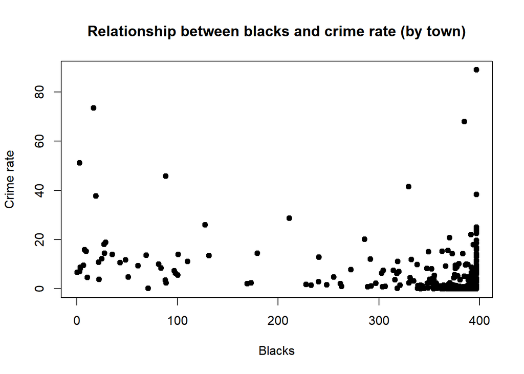

```r
plot(black,crim,main="Relationship between blacks and crime rate (by town)", xlab="Blacks", ylab="Crime rate", pch=19)
```

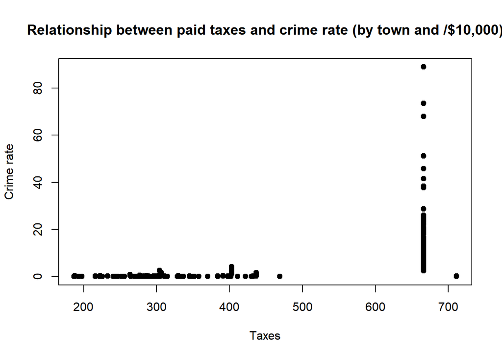

```r
plot(tax,crim,main="Relationship between paid taxes and crime rate (by town and /$10,000)", xlab="Taxes", ylab="Crime rate", pch=19)
```

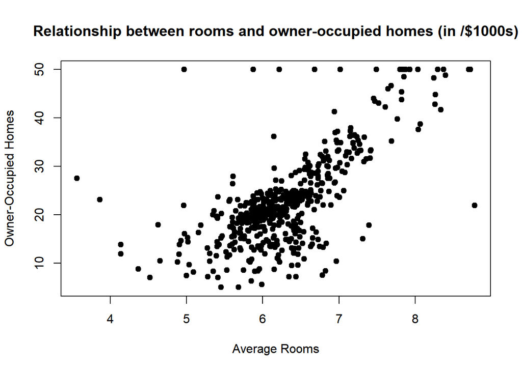

```r
plot(rm,medv,main="Relationship between rooms and owner-occupied homes (in /$1000s)", xlab="Average Rooms", ylab="Owner-Occupied Homes", pch=19)
```

## Any suburbs with particularly high crime rate? Tax rates? Pupil-teacher ratios?

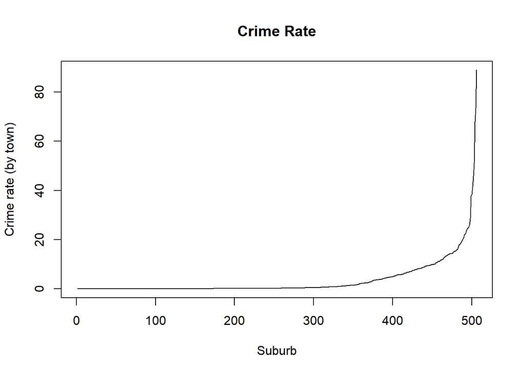

```r
#x-axis has no meaning

plot(Boston[order(Boston$crim),]$crim,main="Crime Rate", xlab="Suburb", ylab="Crime rate (by town)", pch=19,type='l')
```

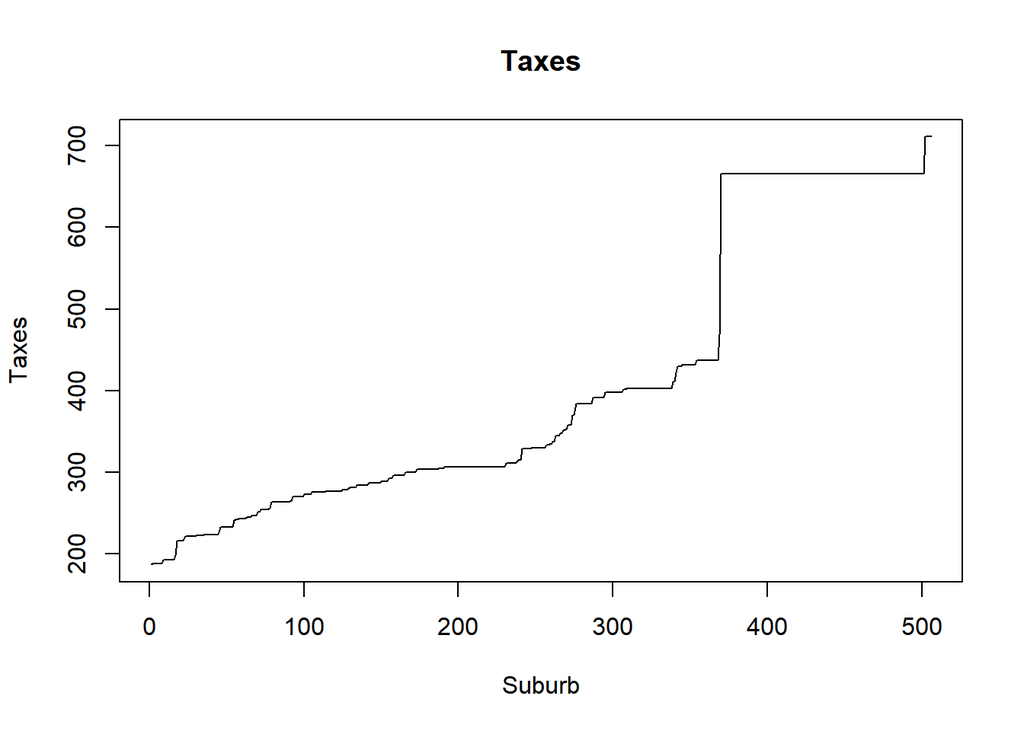

```r
plot(Boston[order(Boston$tax),]$tax,main="Taxes", xlab="Suburb", ylab="Taxes", pch=19,type='l')
```

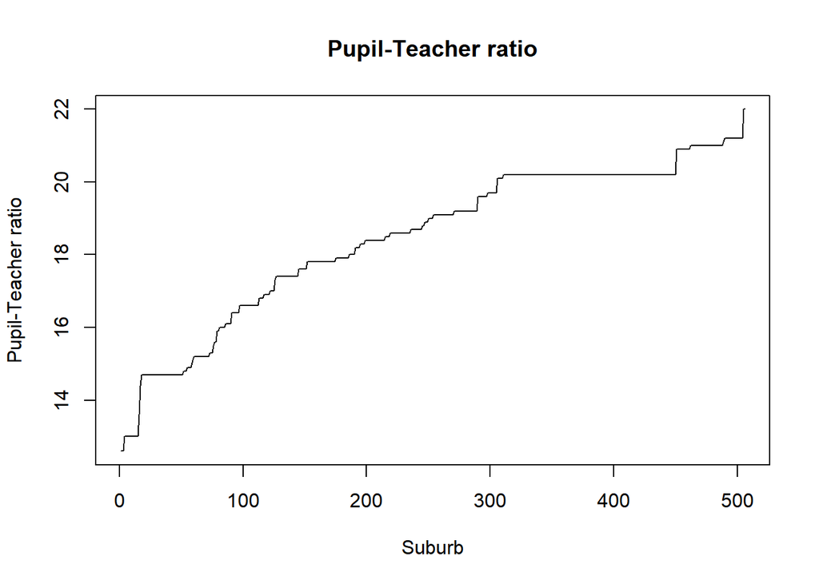

```r
plot(Boston[order(Boston$ptratio),]$ptratio,main="Pupil-Teacher ratio", xlab="Suburb", ylab="Pupil-Teacher ratio", pch=19,type='l')
```

One can observe suburbs with really high values and almost exponential slope for the column crime rate.

## Some Statistics

```r
cat("Number of suburbs bound the Charles river: ",sum(Boston$chas==1))
```

```
## Number of suburbs bound the Charles river:  35
```

```r
cat("Median value of pupil-teacher ratio : ",median(Boston$ptratio))
```

```
## Median value of pupil-teacher ratio :  19.05
```

```r
cat("Lowest median value of owner-occupied homes : ",min(Boston$medv))
```

```
## Lowest median value of owner-occupied homes :  5
```

```r
cat("Number of suburbs with more than 7 rooms per dwelling: ",sum(Boston$rm > 7))
```

```
## Number of suburbs with more than 7 rooms per dwelling:  64
```

```r
cat("Number of suburbs with more than 8 rooms per dwelling: ",sum(Boston$rm > 8))
```

```
## Number of suburbs with more than 8 rooms per dwelling:  13
```

```r
Boston[Boston$rm > 8,]
```

```
##        crim zn indus chas    nox    rm  age    dis rad tax ptratio  black
## 98  0.12083  0  2.89    0 0.4450 8.069 76.0 3.4952   2 276    18.0 396.90
## 164 1.51902  0 19.58    1 0.6050 8.375 93.9 2.1620   5 403    14.7 388.45
## 205 0.02009 95  2.68    0 0.4161 8.034 31.9 5.1180   4 224    14.7 390.55
## 225 0.31533  0  6.20    0 0.5040 8.266 78.3 2.8944   8 307    17.4 385.05
## 226 0.52693  0  6.20    0 0.5040 8.725 83.0 2.8944   8 307    17.4 382.00
## 227 0.38214  0  6.20    0 0.5040 8.040 86.5 3.2157   8 307    17.4 387.38
## 233 0.57529  0  6.20    0 0.5070 8.337 73.3 3.8384   8 307    17.4 385.91
## 234 0.33147  0  6.20    0 0.5070 8.247 70.4 3.6519   8 307    17.4 378.95
## 254 0.36894 22  5.86    0 0.4310 8.259  8.4 8.9067   7 330    19.1 396.90
## 258 0.61154 20  3.97    0 0.6470 8.704 86.9 1.8010   5 264    13.0 389.70
## 263 0.52014 20  3.97    0 0.6470 8.398 91.5 2.2885   5 264    13.0 386.86
## 268 0.57834 20  3.97    0 0.5750 8.297 67.0 2.4216   5 264    13.0 384.54
## 365 3.47428  0 18.10    1 0.7180 8.780 82.9 1.9047  24 666    20.2 354.55
##     lstat medv
## 98   4.21 38.7
## 164  3.32 50.0
## 205  2.88 50.0
## 225  4.14 44.8
## 226  4.63 50.0
## 227  3.13 37.6
## 233  2.47 41.7
## 234  3.95 48.3
## 254  3.54 42.8
## 258  5.12 50.0
## 263  5.91 48.8
## 268  7.44 50.0
## 365  5.29 21.9
```

```r
#compare some data
Boston[Boston$medv==min(Boston$medv),]
```

```
##        crim zn indus chas   nox    rm age    dis rad tax ptratio  black
## 399 38.3518  0  18.1    0 0.693 5.453 100 1.4896  24 666    20.2 396.90
## 406 67.9208  0  18.1    0 0.693 5.683 100 1.4254  24 666    20.2 384.97
##     lstat medv
## 399 30.59    5
## 406 22.98    5
```

The data with more than 8 rooms have a low crime rate and high values for age, tax, black for example. The 2 suburbs with the lowest medv values have high values for the predictors crime, black, tax, pt-ratio. One can conclude that populations with a lower status and cheap houses are at increased risk of being a crime victim.

# Fit a Regression tree using column medv as outcome variable

```r
#Note: outcome variable should be continuous. Exercise follows Lab 8.3.2 in James et al.
set.seed(1) #set a fix random generator to reproduce the same results next time
train = sample(1:nrow(Boston), nrow(Boston)/2)   #split data randomly
tree.boston = rpart(medv ~.,Boston,subset=train) # create a tree
print(tree.boston) #only 3 variables were used
```

```
## n= 253
##
## node), split, n, deviance, yval
##       * denotes terminal node
##
##  1) root 253 20894.66000 22.67312
##    2) lstat>=9.715 150  3464.71500 17.55133
##      4) lstat>=21.49 30   311.88970 11.10333 *
##      5) lstat< 21.49 120  1593.69900 19.16333
##       10) lstat>=14.48 58   743.28220 17.15690 *
##       11) lstat< 14.48 62   398.48920 21.04032 *
##    3) lstat< 9.715 103  7764.58400 30.13204
##      6) rm< 7.437 89  3310.16000 27.57640
##       12) rm< 6.7815 61  1994.62200 25.52131
##         24) dis>=2.85155 54   544.00830 24.32778
##           48) rm< 6.36 22    47.17864 21.82273 *
##           49) rm>=6.36 32   263.86000 26.05000 *
##         25) dis< 2.85155 7   780.27430 34.72857 *
##       13) rm>=6.7815 28   496.64960 32.05357 *
##      7) rm>=7.437 14   177.84360 46.37857 *
```

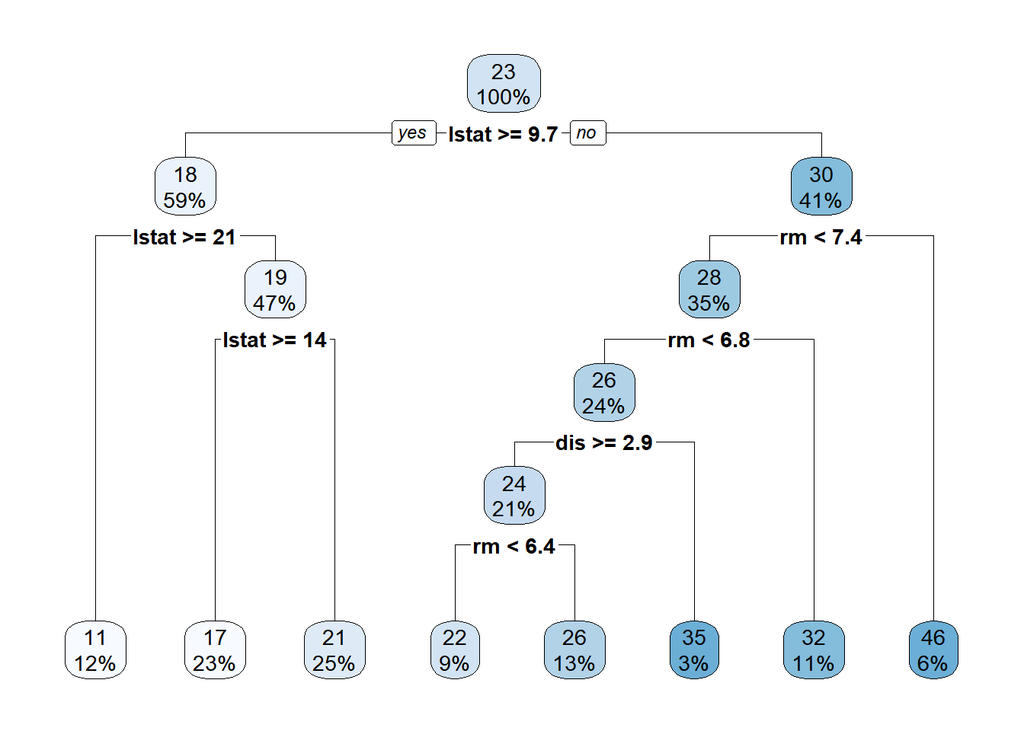

```r
rpart.plot(tree.boston)
```

The tree indicates that a higher socioeconomic status leads in buying more expensive houses. A median house price of $46,000 can be observed when lstat is lower than 9.7% and number of rooms are higher than 7.4 on average.

## Can pruning the tree improve our model?

Rule: Choose the smalles number of nodes (largest cp value) which lies within 1 std. dev. of the smallest deviance, i.e. lies below the dotted line.

```r
printcp(tree.boston)
```

```
##
## Regression tree:
## rpart(formula = medv ~ ., data = Boston, subset = train)
##
## Variables actually used in tree construction:
## [1] dis   lstat rm
##
## Root node error: 20895/253 = 82.588
##
## n= 253
##
##         CP nsplit rel error  xerror     xstd
## 1 0.462576      0   1.00000 1.01273 0.117728
## 2 0.204673      1   0.53742 0.56339 0.059699
## 3 0.074618      2   0.33275 0.34949 0.039945
## 4 0.039191      3   0.25813 0.29608 0.039976
## 5 0.032082      4   0.21894 0.31072 0.048076
## 6 0.021629      5   0.18686 0.29508 0.048053
## 7 0.011150      6   0.16523 0.26146 0.042604
## 8 0.010000      7   0.15408 0.25032 0.037014
```

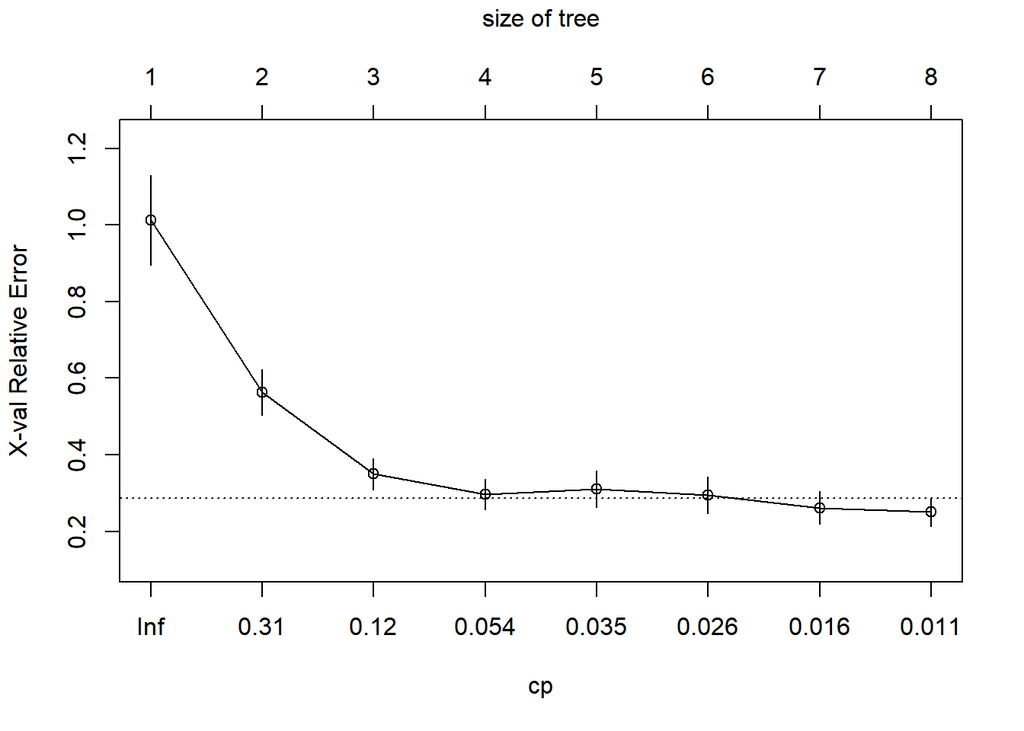

```r
plotcp(tree.boston)
```

cp=0.016 lies below the dotted line and could improve our model

## Prune the tree and compare models

```r
prune.boston = prune(tree.boston,cp=0.016)
prune.boston
```

```
## n= 253
##
## node), split, n, deviance, yval
##       * denotes terminal node
##
##  1) root 253 20894.6600 22.67312
##    2) lstat>=9.715 150  3464.7150 17.55133
##      4) lstat>=21.49 30   311.8897 11.10333 *
##      5) lstat< 21.49 120  1593.6990 19.16333
##       10) lstat>=14.48 58   743.2822 17.15690 *
##       11) lstat< 14.48 62   398.4892 21.04032 *
##    3) lstat< 9.715 103  7764.5840 30.13204
##      6) rm< 7.437 89  3310.1600 27.57640
##       12) rm< 6.7815 61  1994.6220 25.52131
##         24) dis>=2.85155 54   544.0083 24.32778 *
##         25) dis< 2.85155 7   780.2743 34.72857 *
##       13) rm>=6.7815 28   496.6496 32.05357 *
##      7) rm>=7.437 14   177.8436 46.37857 *
```

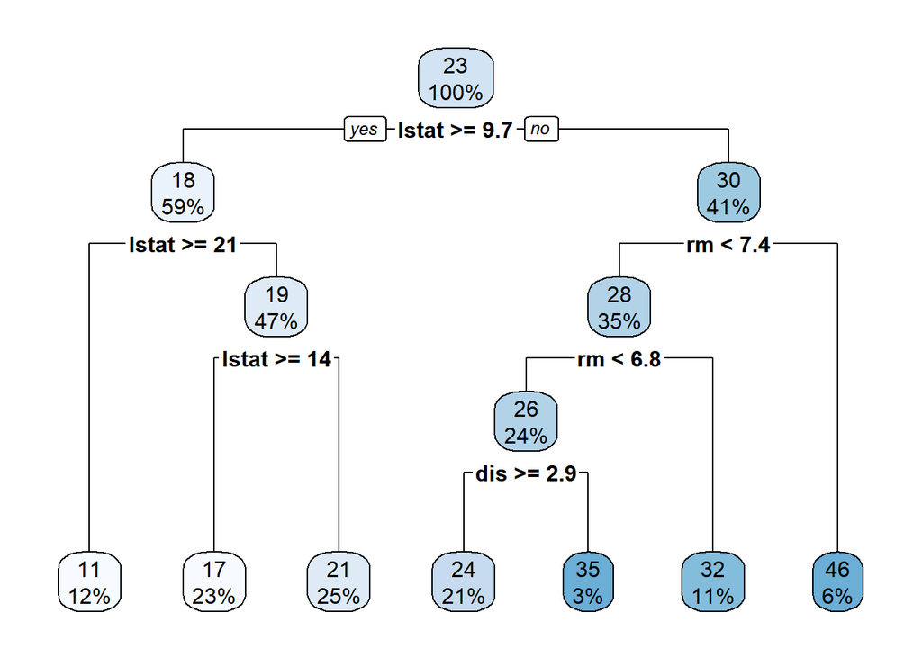

```r
rpart.plot(prune.boston)
```

```r
#compare models by calculating MSE (Mean Squarred Error)
pred.train<-predict(tree.boston,newdata=Boston[train,])
mean((Boston$medv[train]-pred.train)^2)
```

```
## [1] 12.72517
```

```r
pred.train.prune<-predict(prune.boston,newdata=Boston[train,])
mean((Boston$medv[train]-pred.train.prune)^2)
```

```
## [1] 13.646
```

## Calculate the MSE for the test set

```r
pred.test<-predict(tree.boston,newdata=Boston[-train,])
mean((Boston$medv[-train]-pred.test)^2)
```

```
## [1] 25.35825
```

```r
pred.test<-predict(prune.boston,newdata=Boston[-train,])
mean((Boston$medv[-train]-pred.test)^2)
```

```
## [1] 25.82207
```

Pruned tree performes slightly worse applied on train and test set, but we gained a simpler model. Taking the square root of the test set MSE gives $5,000 rounded. That’s the range where test prediction lay in.

## Plot observed median values medv agains predictions

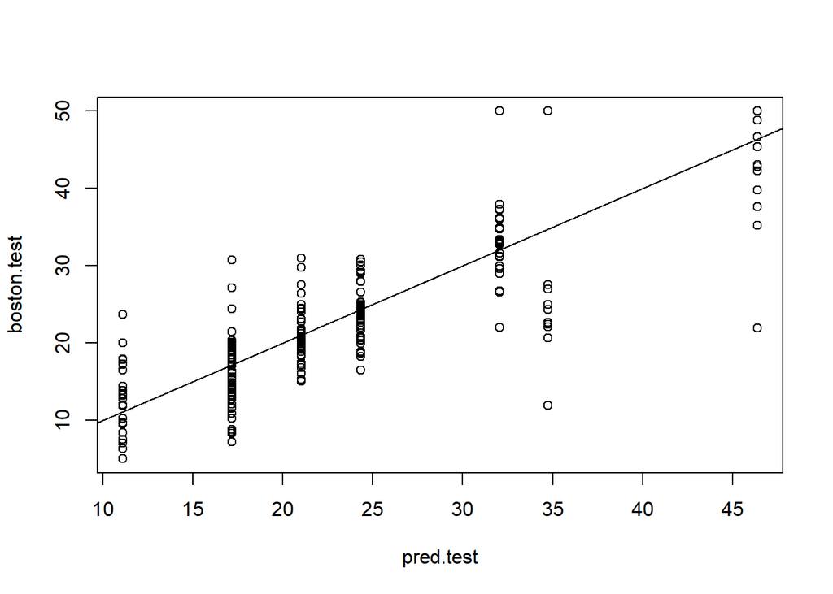

```r
boston.test=Boston[-train,"medv"]
plot(pred.test,boston.test)
abline(c(0,1))
```

# Classification Tree: Prostate Cancer

Did the cancer recur after surgical removal of the postate?

Used data set: stagec #from package rpart

```r
head(stagec)
```

```
##   pgtime pgstat age eet    g2 grade gleason     ploidy
## 1    6.1      0  64   2 10.26     2       4    diploid
## 2    9.4      0  62   1    NA     3       8  aneuploid
## 3    5.2      1  59   2  9.99     3       7    diploid
## 4    3.2      1  62   2  3.57     2       4    diploid
## 5    1.9      1  64   2 22.56     4       8 tetraploid
## 6    4.8      0  69   1  6.14     3       7    diploid
```

```r
cat("Number of rows: ", nrow(stagec))
```

```
## Number of rows:  146
```

```r
cat("Number of columns: ", ncol(stagec))
```

```
## Number of columns:  8
```

```r
cat("Column names: ", colnames(stagec))
```

```
## Column names:  pgtime pgstat age eet g2 grade gleason ploidy
```

```r
cat("Recurrence of the disease: ",table(stagec$pgstat))
```

```
## Recurrence of the disease:  92 54
```

The column pgstat is the outcome of interest.

## Factorize the outcome variable & show some plots

Instead of having numerical values, we would rather have “No” and “Prog”. This makes reading the output easier and rpart will recognise that the outcome variable is a factor variable and so will use the Gini coefficient to calculate the loss statistic, in order to determine each splits. As pgstat is numeric rpart would assume that a regression tree is wanted, and will use mean square error for the loss function.

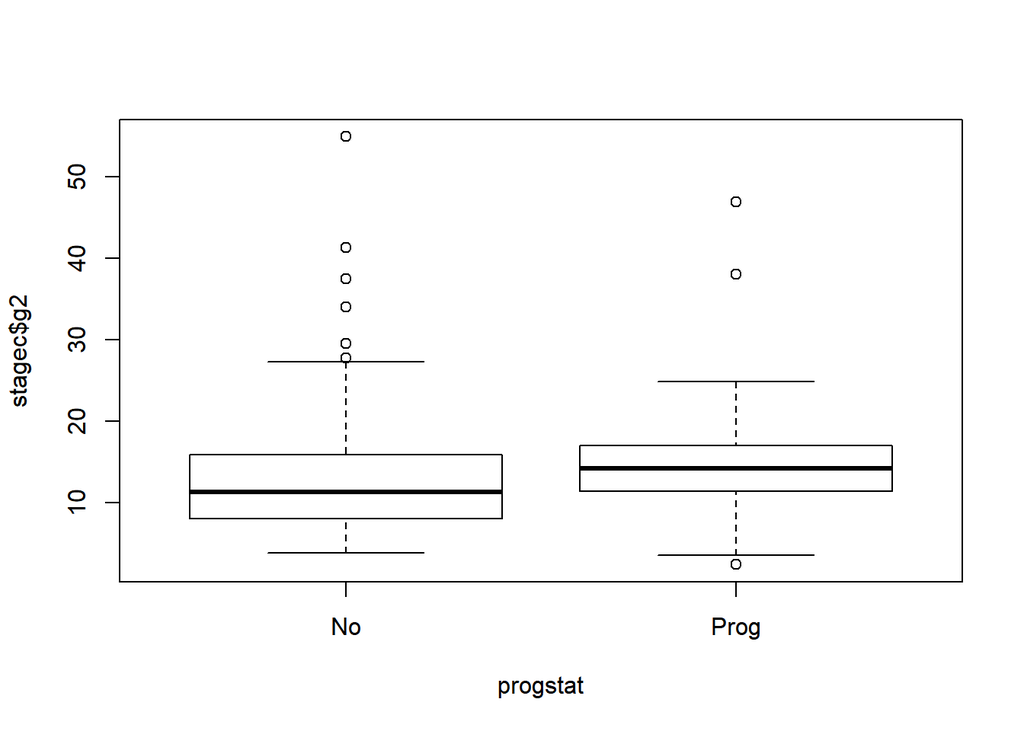

```r
stagec$progstat <- factor(stagec$pgstat, levels = 0:1, labels = c("No", "Prog"))
plot(stagec$g2~progstat,data=stagec )
```

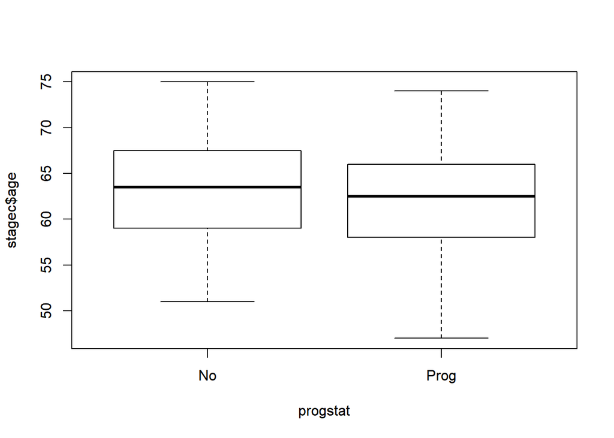

```r
plot(stagec$age~progstat,data=stagec )
```

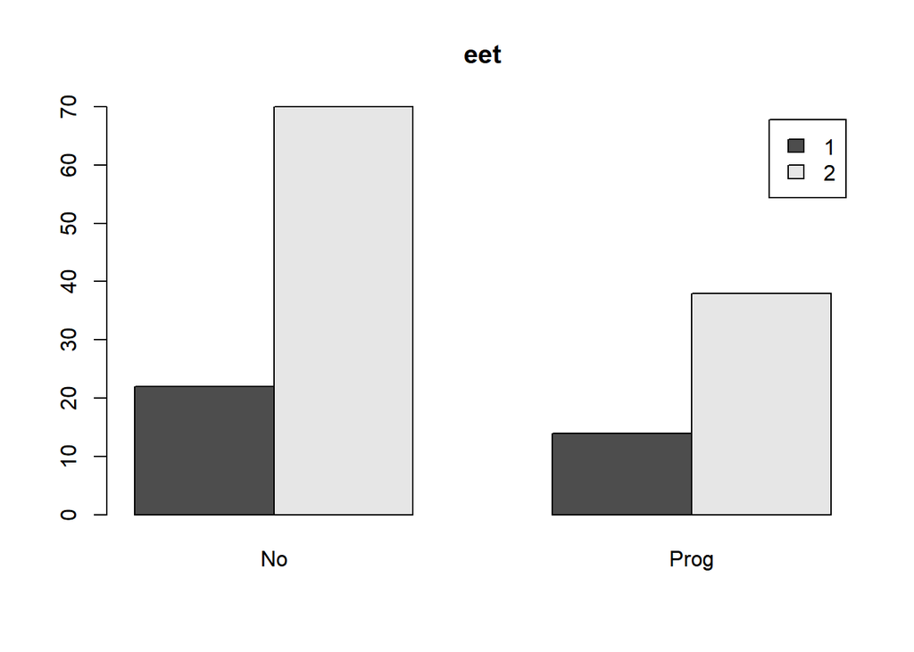

```r
barplot(table(stagec$eet,stagec$progstat),beside=TRUE,legend.text=TRUE,main="eet" )
```

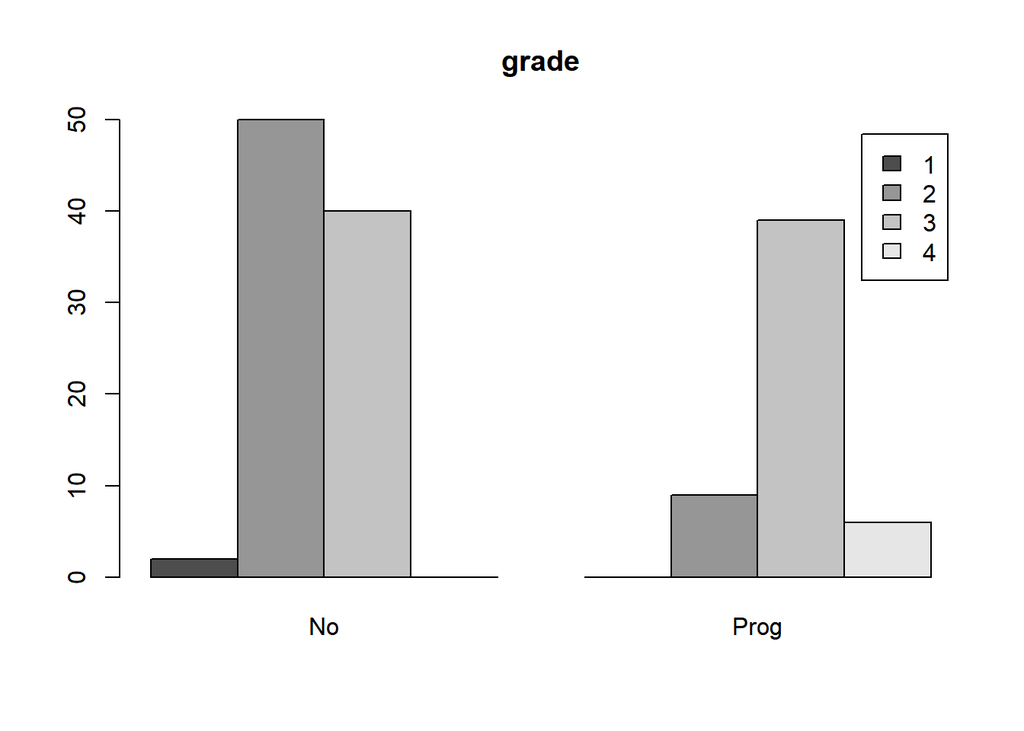

```r
barplot(table(stagec$grade,stagec$progstat),beside=TRUE,legend.text=TRUE,main="grade" )
```

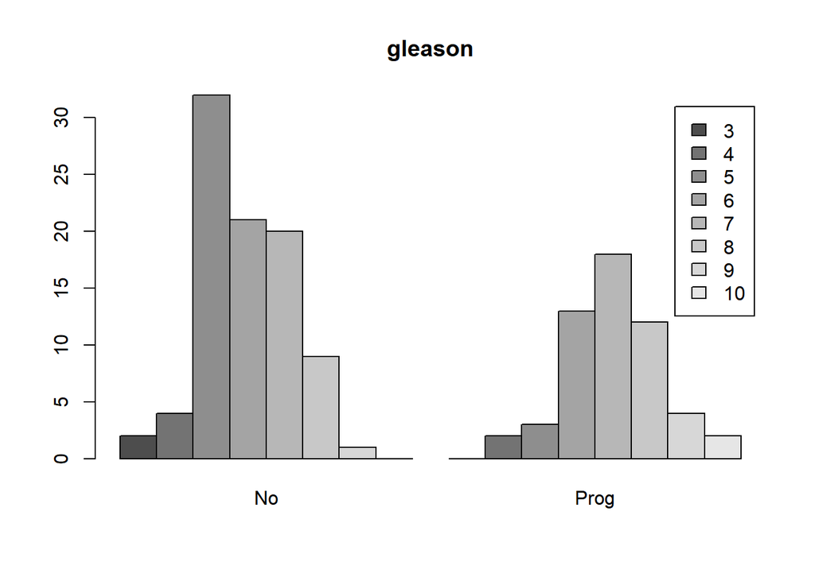

```r
barplot(table(stagec$gleason,stagec$progstat),beside=TRUE,legend.text=TRUE,main="gleason" )
```

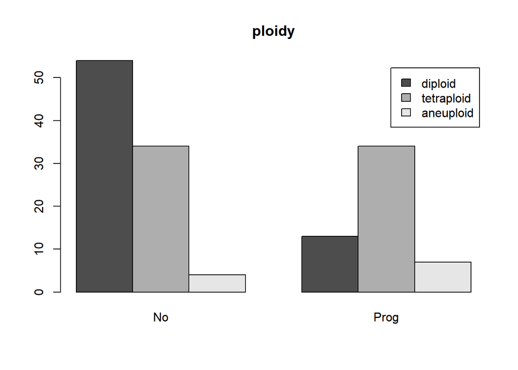

```r
barplot(table(stagec$ploidy,stagec$progstat),beside=TRUE,legend.text=TRUE,main="ploidy" )
```

## Training set

We use the whole data set, because we only have 146 observations.

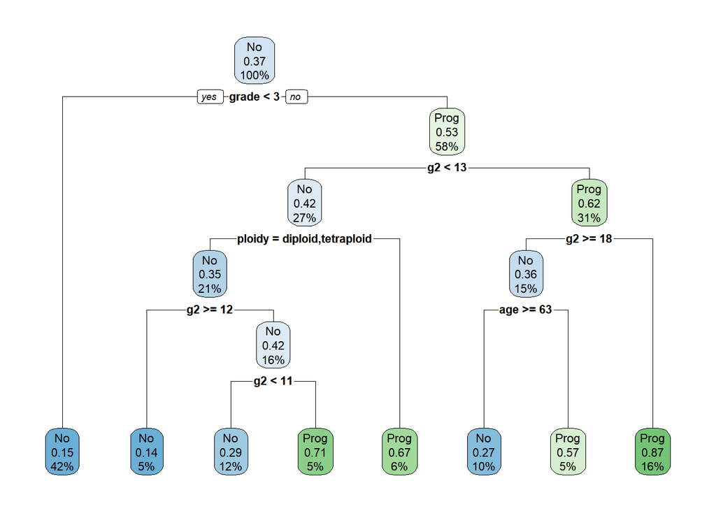

```r
c.tree <- rpart(progstat ~ age + eet + g2 + grade + gleason + ploidy,data = stagec)
rpart.plot(c.tree)
```

```r
print(c.tree)
```

```
## n= 146
##
## node), split, n, loss, yval, (yprob)
##       * denotes terminal node
##
##  1) root 146 54 No (0.6301370 0.3698630)
##    2) grade< 2.5 61  9 No (0.8524590 0.1475410) *
##    3) grade>=2.5 85 40 Prog (0.4705882 0.5294118)
##      6) g2< 13.2 40 17 No (0.5750000 0.4250000)
##       12) ploidy=diploid,tetraploid 31 11 No (0.6451613 0.3548387)
##         24) g2>=11.845 7  1 No (0.8571429 0.1428571) *
##         25) g2< 11.845 24 10 No (0.5833333 0.4166667)
##           50) g2< 11.005 17  5 No (0.7058824 0.2941176) *
##           51) g2>=11.005 7  2 Prog (0.2857143 0.7142857) *
##       13) ploidy=aneuploid 9  3 Prog (0.3333333 0.6666667) *
##      7) g2>=13.2 45 17 Prog (0.3777778 0.6222222)
##       14) g2>=17.91 22  8 No (0.6363636 0.3636364)
##         28) age>=62.5 15  4 No (0.7333333 0.2666667) *
##         29) age< 62.5 7  3 Prog (0.4285714 0.5714286) *
##       15) g2< 17.91 23  3 Prog (0.1304348 0.8695652) *
```

## Pruning the Tree

As with the regression tree we should look to see if pruning the tree gives us a better model.

```r
printcp(c.tree)
```

```
##
## Classification tree:
## rpart(formula = progstat ~ age + eet + g2 + grade + gleason +
##     ploidy, data = stagec)
##
## Variables actually used in tree construction:
## [1] age    g2     grade  ploidy
##
## Root node error: 54/146 = 0.36986
##
## n= 146
##
##         CP nsplit rel error  xerror    xstd
## 1 0.104938      0   1.00000 1.00000 0.10802
## 2 0.055556      3   0.68519 0.88889 0.10511
## 3 0.027778      4   0.62963 0.94444 0.10668
## 4 0.018519      6   0.57407 0.96296 0.10715
## 5 0.010000      7   0.55556 0.94444 0.10668
```

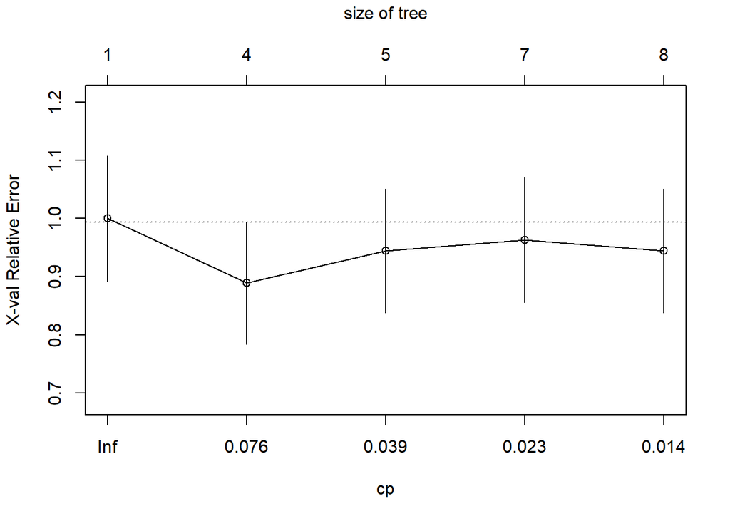

```r
plotcp(c.tree)
```

```r
c.pruned<-prune(c.tree,cp=0.076)
print(c.pruned)
```

```
## n= 146
##
## node), split, n, loss, yval, (yprob)
##       * denotes terminal node
##
##  1) root 146 54 No (0.6301370 0.3698630)
##    2) grade< 2.5 61  9 No (0.8524590 0.1475410) *
##    3) grade>=2.5 85 40 Prog (0.4705882 0.5294118)
##      6) g2< 13.2 40 17 No (0.5750000 0.4250000) *
##      7) g2>=13.2 45 17 Prog (0.3777778 0.6222222)
##       14) g2>=17.91 22  8 No (0.6363636 0.3636364) *
##       15) g2< 17.91 23  3 Prog (0.1304348 0.8695652) *
```

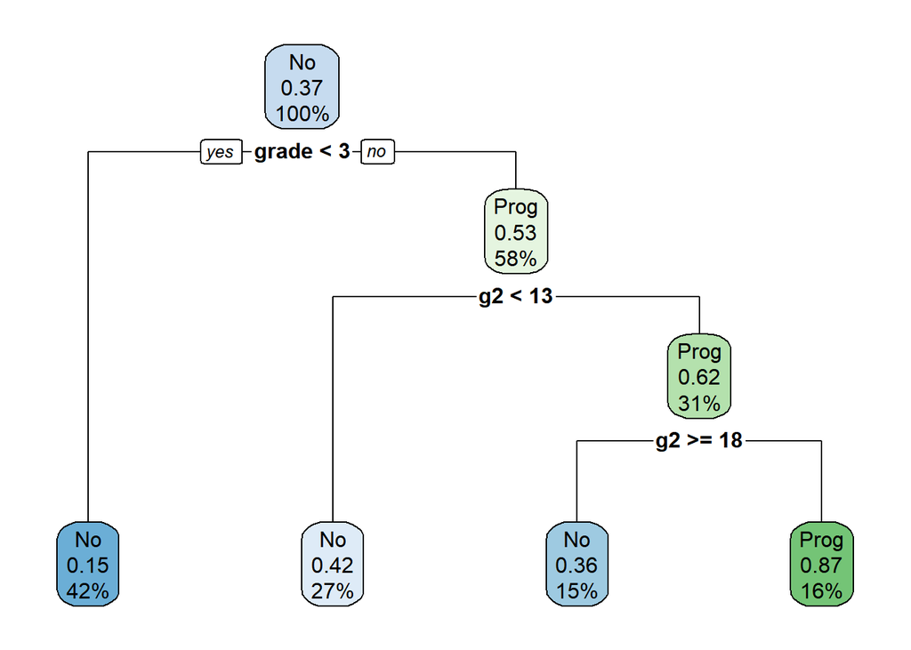

```r
rpart.plot(c.pruned)
```

## Make predictions

We now set alpha = 0.5 to get the most likely of the two outcomes

```r
alpha <- 0.5 #0.4
stagec$predict<-(predict(c.pruned)[,2]>alpha)
tt<-table(stagec$progstat,stagec$predict)
print(tt)
```

```
##
##        FALSE TRUE
##   No      89    3
##   Prog    34   20
```

```r
sens<-tt[2,2]/sum(tt[2,])
spec<-tt[1,1]/sum(tt[1,])
cat("sensitivity: ",sens,"specificity: ", spec, "sum: ", sens+spec)
```

```
## sensitivity:  0.3703704 specificity:  0.9673913 sum:  1.337762
```

```r
fpr <-tt[1,2]/sum(tt[,2]) #false-positive rate
```

The value of the specificity is fairly high with ~97%. It tells us how many healthy people were correctly identified as not having the condition. Whereas one cannot take into account the sensitivity. One might be more interested in detecting the patients with progression to consider further treatments.

## Draw ROC diagram and AUC

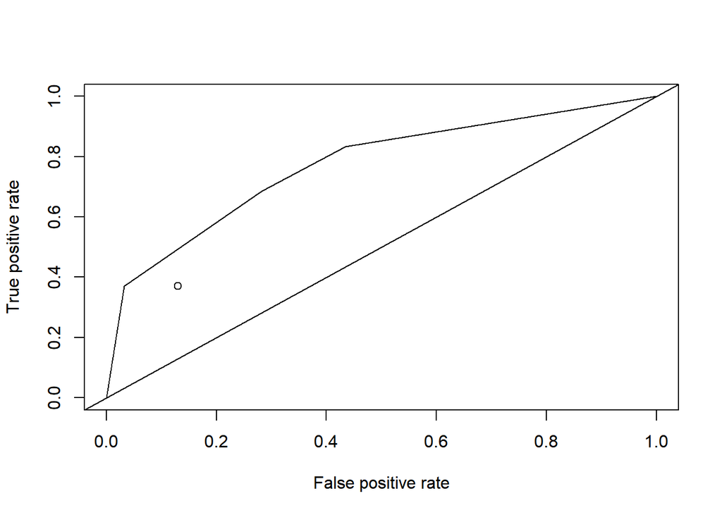

```r
p <- predict(c.pruned)[,2]
#rpart function to get the prediction for Yes
pr <- prediction(p, stagec$progstat) #convert the predictions into ROCR format
prf <- performance(pr, measure = "tpr", x.measure = "fpr")
#ROCR function calculates everything for the ROC curve
plot(prf) #plot the ROC curve
abline(c(0,1))
points(fpr,sens)
```

```r
AUC<-performance(pr, measure ="auc")@y.values[[1]];AUC
```

```
## [1] 0.7716385
```

```r
#RORC function calculates the AUC
```

Our model is above the diagonal and therefore better than tossing a coin. However, one might be rather interested in detecting the patients with progression. One can change the alpha value to get another model. If you set alpha to 0.4, then your sensitivity becomes larger, but your specificity smaller at the same time. It is similar of saying ‘progression is true’ each time unless there are convinving values against it. If you toss a coin and say that 80% of the events are head, then you are really good at predicting head, but not for tail.